# data.table – Yet Another Performance Approach for Large Data Frames

## Agenda

- What is a data.table
- Why would we use it
- How do I use it
- Comparison to **dplyr** and other **base** functions

## What is a data table

Matt Dowle created the **data.table** package to provide increased performance in handling data that is organized in a **data.frame**. The **data.frame** is one of the primary objects used in **R** for containing the various components of data that is analyzed.

**data.frame** are very similar to **Excel** spreadsheet, or relation **tables**. They contain data that is in a tabular form and allow access to the individual rows/columns of information. You can also access the information is a similar fashion to matrices, but there is a performance penalty that you have to pay.

Also when changing/modifying the data in a data.frame, a copy of the entire object may have to be made, increasing the time that it takes to do some operations **data.tables** tries to minimize the amount of copying that is done by just copying the **column** of data instead of the entire object.

So what **data.table** provides is fast aggregation of the information when compared to what can be done with the **base** functions in **R**. When comparing the performance to what is possible with **dplyr**, there has been friendly competition between Matt Dowle and Hadley Wickham when it comes to benchmarking **data.table** vs. **dplyr**, which has lead to better performance in both of these packages.

### Quick Overview of a **data.table**

One of the things that you have to get use to with **data.table** is it’s *funky* syntax. When you use **dplyr**, you **chain/pipe** together various functions/verbs which do transformations on the data, very much like you *pipe* command together on a LINUX/UNIX/WINDOWS command line.

Here is what the basic syntax of a **data.table** command looks like in terms that might be used in an SQL statement:

DT[where, select/update/do, by]

What is happening is that **data.table** is **overloading** the **[** operator. I think part of the reason for this is that is one of the ways that **data.table** gets its performance gains since it captures control early in the processing, and then redefines how the processing of the positional parameters inside the **[**’s are handled.

So you are no longer thinking about the first and second parameters to **[** as **row/column**, but for **data.table** they are the **where** clause like for **SQL** and the operation that you want to carry out.

Here is what the help page shows for **?data.table**:

```
Usage

data.table(..., keep.rownames=FALSE, check.names=FALSE, key=NULL)

## S3 method for class 'data.table'
x[i, j, by, keyby, with = TRUE,
  nomatch = getOption("datatable.nomatch"),                   # default: NA_integer_
  mult = "all",
  roll = FALSE,
  rollends = if (roll=="nearest") c(TRUE,TRUE)
             else if (roll>=0) c(FALSE,TRUE)
             else c(TRUE,FALSE),
  which = FALSE,
  .SDcols,
  verbose = getOption("datatable.verbose"),                   # default: FALSE
  allow.cartesian = getOption("datatable.allow.cartesian"),   # default: FALSE
  drop = NULL,
  on = NULL # join without setting keys, new feature from v1.9.6+
  ]
```

You first see that there are a lot of parameters that are now defined inside the square brackets (**[]**). There is still an **i** and **j**, but these are not necessarily the **row** and **column** indices. If you look at the definition of **i**, you get:

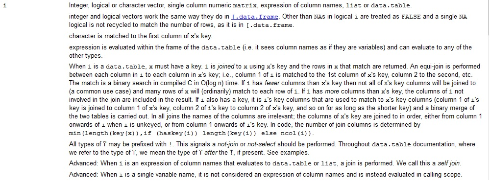

which covers a number of different ways of using/accessing data within a **data.table**. There are also a large number of good tutorials out there that I used to pull together some of the things that have gone into this talk.

## Basic Use Similar to a Data Frame

- When defining a **data.table** one of the nice defaults is that it sets **stringsAsFactors = FALSE**; this means that *character* vectors will be **character** instead of **factor** which can create problems if you don’t know what a **factor** is, or not using the data as part of a regression function.

```r
library(data.table)  # make sure it is loaded
set.seed(100)  # so we get the same random numbers

# define a data.table with 100K rows
n <- 100000
myDT <- data.table(id = sample(300, n, TRUE),
                   char_id = sample(LETTERS, n, TRUE),
                   value = rnorm(n)
)

str(myDT)
```

```
## Classes 'data.table' and 'data.frame':   100000 obs. of  3 variables:
##  $ id     : int  93 78 166 17 141 146 244 112 164 52 ...
##  $ char_id: chr  "L" "F" "T" "B" ...
##  $ value  : num  -1.3561 -0.8468 -2.6961 0.0378 0.5059 ...
##  - attr(*, ".internal.selfref")=<externalptr>
```

```r
# select a subset of the data:  id == 100
# notice I did not say "myDT[myDT$id == 100,]" as I would with a data.frame
# also data.table knows that 'id' is in it, so I don't have to qualify the name

id_100 <- myDT[id == 100]
str(id_100)
```

```
## Classes 'data.table' and 'data.frame':   377 obs. of  3 variables:
##  $ id     : int  100 100 100 100 100 100 100 100 100 100 ...
##  $ char_id: chr  "S" "S" "N" "N" ...
##  $ value  : num  -0.502 0.872 -1.752 -1.046 -0.984 ...
##  - attr(*, ".internal.selfref")=<externalptr>
```

I had mentioned that **data.table** has a **funky** syntax that you have to get used to. Here is one of the things that you have to be careful of when working with **data.table**s even those, in most cases, they can be used anywhere that **data.frame**s are used.

The example below shows how the row/column indexing that you might be using with a **data.frame** can get you in trouble. The reason is that the second parameter in the **data.table**:

DT[where, **select/update/do**, by]  
is evaluated in the context of the **data.table**, and it not taken as the column name/number as it would be in a **data.frame**

```r
# I can get row 1 with the typical data.frame access
myDT[1, ]  # get row 1
```

```
##    id char_id     value
## 1: 93       L -1.356072
```

```r
# but if I try to get the second column, I don't get what I expect
myDT[1, 2]  # expecting "A", but get "2" which is the value of the second parameter
```

```
## [1] 2
```

```r
# have to use "with = FALSE" to access like a data.frame
myDT[1, 2, with = FALSE]  # now I get back a LETTER
```

```
##    char_id
## 1:       L
```

```r
# BTW it does work if you use the unquoted name of the column
myDT[1, char_id]  # unquoted
```

```
## [1] "L"
```

```r
# but if you quote it, as you might using data.frame, you just get back the string value
myDT[1, "char_id"]
```

```
## [1] "char_id"
```

```r
# so just don't use the 'row/column' indexing as you might with a data.frame
# for the data.table without 'with = FALSE'

# now if you are going to make frequent access to the data.table with a
# pair of keys char_id and id, you can set those as the key and this
# will order the table for faster access

setkey(myDT, char_id, id)  # set the key
myDT[list("A", 100)]  # retrieve with char_id == "A" and id == 100
```

```
##     id char_id       value
## 1: 100       A -1.77106114
## 2: 100       A  0.04567828
## 3: 100       A -0.02042340
## 4: 100       A -0.04718014
## 5: 100       A  0.52364616
```

```r
# set the values dynamically
char_key <- "A"
id_key <- 100
myDT[list(char_key, id_key)]
```

```
##     id char_id       value
## 1: 100       A -1.77106114
## 2: 100       A  0.04567828
## 3: 100       A -0.02042340
## 4: 100       A -0.04718014
## 5: 100       A  0.52364616
```

```r
# or I might have a list of items that I want to retrieve; for example, I will construct
# a list of 26 conditions so for the 26 LETTERS, I want to retrieve the index 1:26 paired
# with each LETTER
search <- list(LETTERS, 1:26)
x <- myDT[search]  # find those index values -- binary search, very fast
str(x)  # how many did we get back
```

```
## Classes 'data.table' and 'data.frame':   352 obs. of  3 variables:
##  $ id     : int  1 1 1 1 1 1 1 1 1 1 ...
##  $ char_id: chr  "A" "A" "A" "A" ...
##  $ value  : num  -0.867 -0.822 -0.415 0.532 0.281 ...
##  - attr(*, "sorted")= chr  "char_id" "id"
##  - attr(*, ".internal.selfref")=<externalptr>
```

```r
# now pick off the first value for each unique key pair
# '.' is shorthand for 'list'
x[, .(first = value[1L]), keyby = .(char_id, id)]
```

```
##     char_id id       first
##  1:       A  1 -0.86707022
##  2:       B  2  1.75626218
##  3:       C  3  0.99148429
##  4:       D  4 -0.10267587
##  5:       E  5  0.14089959
##  6:       F  6  0.02322650
##  7:       G  7  2.27208676
##  8:       H  8  1.12870402
##  9:       I  9 -0.48580614
## 10:       J 10 -0.13283831
## 11:       K 11 -1.97832708
## 12:       L 12  0.57097945
## 13:       M 13  0.25439918
## 14:       N 14  1.00417409
## 15:       O 15  1.90731478
## 16:       P 16 -2.45363619
## 17:       Q 17 -0.78359585
## 18:       R 18 -0.37305030
## 19:       S 19  1.31427838
## 20:       T 20  1.31887420
## 21:       U 21 -0.63021292
## 22:       V 22  0.36634818
## 23:       W 23 -0.02100636
## 24:       X 24 -0.32857586
## 25:       Y 25  0.59328618
## 26:       Z 26 -0.96493281
##     char_id id       first
```

```r
# now if you have a dataframe and you want to add a new column,
# you use the "$" operator as below
df <- data.frame(id = 1:10, value = runif(10))

# add new column with value multiplied by 2
address(df)  # this is to show that a copy is made of the data.frame to create the new column
```

```
## [1] "00000000066851F0"
```

```r
df$v2 <- df$value * 2
address(df)  # notice that the dataframe has been copied in adding the column
```

```
## [1] "0000000006616748"
```

```r
str(df)  # see the new column
```

```
## 'data.frame':    10 obs. of  3 variables:
##  $ id   : int  1 2 3 4 5 6 7 8 9 10
##  $ value: num  0.45 0.909 0.144 0.216 0.641 ...
##  $ v2   : num  0.9 1.818 0.287 0.433 1.281 ...
```

```r
# now with the data.table, there is the ':=' assignment operator that
# is used within the brackets.  It will add the column and it will not
# copy the entire object.  This is very important if you object is very
# large

address(myDT)
```

```
## [1] "0000000005F2C0A0"
```

```r
# notice that when using 'knitr', the statement outputs the result to console
# I enclose the statement in "invisible" to prevent the output

invisible(
  myDT[, v2 := value * 2]  # notice the ':=' is used in the second position
)  # keep it from printing the output

address(myDT)  # should be the same
```

```
## [1] "0000000005F2C0A0"
```

```r
str(myDT)
```

```
## Classes 'data.table' and 'data.frame':   100000 obs. of  4 variables:
##  $ id     : int  1 1 1 1 1 1 1 1 1 1 ...
##  $ char_id: chr  "A" "A" "A" "A" ...
##  $ value  : num  -0.867 -0.822 -0.415 0.532 0.281 ...
##  $ v2     : num  -1.734 -1.645 -0.831 1.063 0.561 ...
##  - attr(*, ".internal.selfref")=<externalptr>
##  - attr(*, "sorted")= chr  "char_id" "id"
```

So we see one of the advantages of **data.table** in that copies are not made of the object when it is modified. Now with the data.frame syntax, you can only do a single assignment at a time. But there are ways around it. The **:=** operator is actually a function, so you can call it with multiple parameters to make changes to multiple columns. Let’s say we want to add three more columns to multiply **value** by 3,4,5:

```r
# notice how we call the ':=' function with backquotes (`)
address(myDT)
```

```
## [1] "0000000005F2C0A0"
```

```r
invisible(
  myDT[, `:=`(v3 = value * 3,
              v4 = value * 4,
              v5 = value * 5
  )]  # add/modify multiply columns
)
address(myDT)  # address should be the same
```

```
## [1] "0000000005F2C0A0"
```

```r
str(myDT)
```

```
## Classes 'data.table' and 'data.frame':   100000 obs. of  7 variables:
##  $ id     : int  1 1 1 1 1 1 1 1 1 1 ...
##  $ char_id: chr  "A" "A" "A" "A" ...
##  $ value  : num  -0.867 -0.822 -0.415 0.532 0.281 ...
##  $ v2     : num  -1.734 -1.645 -0.831 1.063 0.561 ...
##  $ v3     : num  -2.601 -2.467 -1.246 1.595 0.842 ...
##  $ v4     : num  -3.47 -3.29 -1.66 2.13 1.12 ...
##  $ v5     : num  -4.34 -4.11 -2.08 2.66 1.4 ...
##  - attr(*, ".internal.selfref")=<externalptr>
##  - attr(*, "sorted")= chr  "char_id" "id"
```

```r
# but you can also "chain" a number of operations on a data.table.  The output
# of an operation on a data.table is another data.table.  Here we add a couple of
# more columns by chaining.  Notice how it is done using the data.table syntax

invisible(
  myDT[, v6 := value * 6][  # notice the "[" for the chaining
    , v7 := value * 7][
    , v8 := value * 8]  # done at this point
)

address(myDT)  # should still be the same address
```

```
## [1] "0000000005F2C0A0"
```

```r
str(myDT)
```

```
## Classes 'data.table' and 'data.frame':   100000 obs. of  10 variables:
##  $ id     : int  1 1 1 1 1 1 1 1 1 1 ...
##  $ char_id: chr  "A" "A" "A" "A" ...
##  $ value  : num  -0.867 -0.822 -0.415 0.532 0.281 ...
##  $ v2     : num  -1.734 -1.645 -0.831 1.063 0.561 ...
##  $ v3     : num  -2.601 -2.467 -1.246 1.595 0.842 ...
##  $ v4     : num  -3.47 -3.29 -1.66 2.13 1.12 ...
##  $ v5     : num  -4.34 -4.11 -2.08 2.66 1.4 ...
##  $ v6     : num  -5.2 -4.93 -2.49 3.19 1.68 ...
##  $ v7     : num  -6.07 -5.76 -2.91 3.72 1.96 ...
##  $ v8     : num  -6.94 -6.58 -3.32 4.25 2.24 ...
##  - attr(*, ".internal.selfref")=<externalptr>
##  - attr(*, "sorted")= chr  "char_id" "id"
```

So we have seen how to add/modify columns to a data.table. By assigning **NULL** to the column, you delete it.

```r
# delete v5
invisible(
  myDT[, v5 := NULL]  # delete the column
)

str(myDT)
```

```
## Classes 'data.table' and 'data.frame':   100000 obs. of  9 variables:
##  $ id     : int  1 1 1 1 1 1 1 1 1 1 ...
##  $ char_id: chr  "A" "A" "A" "A" ...
##  $ value  : num  -0.867 -0.822 -0.415 0.532 0.281 ...
##  $ v2     : num  -1.734 -1.645 -0.831 1.063 0.561 ...
##  $ v3     : num  -2.601 -2.467 -1.246 1.595 0.842 ...
##  $ v4     : num  -3.47 -3.29 -1.66 2.13 1.12 ...
##  $ v6     : num  -5.2 -4.93 -2.49 3.19 1.68 ...
##  $ v7     : num  -6.07 -5.76 -2.91 3.72 1.96 ...
##  $ v8     : num  -6.94 -6.58 -3.32 4.25 2.24 ...
##  - attr(*, ".internal.selfref")=<externalptr>
##  - attr(*, "sorted")= chr  "char_id" "id"
```

## Let’s now do some aggregation with the data

One of the basic operations that you want to perform with data.tables is to partition the data by some element and perform a set of operations on the data. Let’s take the data.table we created, and create the mean and standard deviation of **value** for each **id**. Now in the second position of the data.table access (**select/update/do**), you specify a **list** of the computations you want to perform on the group. In the third position (**by**) you specify the **list** of columns to group by.

```r
# mess up the order since we had sorted it previously
myDT <- myDT[sample(nrow(myDT))]

result <- myDT[, list(mean = mean(value),
                      sd = sd(value),
                      count = .N  # ".N" is the number of elements in the group
              ), by = list(id)]
head(result)
```

```
##     id       mean        sd count
## 1: 147 0.10096581 0.9785957   320
## 2: 180 0.03854346 0.9468589   334
## 3: 285 0.08670721 1.0026817   318
## 4:  73 0.04799054 0.9985999   354
## 5: 209 0.08802420 0.9954376   339
## 6: 273 0.05677867 0.9993007   309
```

```r
str(result)  # should get 300 rows of data
```

```
## Classes 'data.table' and 'data.frame':   300 obs. of  4 variables:
##  $ id   : int  147 180 285 73 209 273 274 293 243 44 ...
##  $ mean : num  0.101 0.0385 0.0867 0.048 0.088 ...
##  $ sd   : num  0.979 0.947 1.003 0.999 0.995 ...
##  $ count: int  320 334 318 354 339 309 314 303 320 359 ...
##  - attr(*, ".internal.selfref")=<externalptr>
```

```r
# if I wanted to sort the output by the 'count' field, I can "chain" it onto
# the command
result <- myDT[, list(mean = mean(value),
                      sd = sd(value),
                      count = .N  # ".N" is the number of elements in the group
              ), by = list(id)][order(count)]  # see how it was added
head(result)
```

```
##     id        mean        sd count
## 1: 161  0.09449230 0.9474307   287
## 2: 120  0.06266965 1.0320105   290
## 3: 290  0.05018502 1.0477183   291
## 4: 169  0.07390673 1.0325095   292
## 5: 191 -0.06318606 1.0309522   295
## 6: 194 -0.02632077 1.0227297   296
```

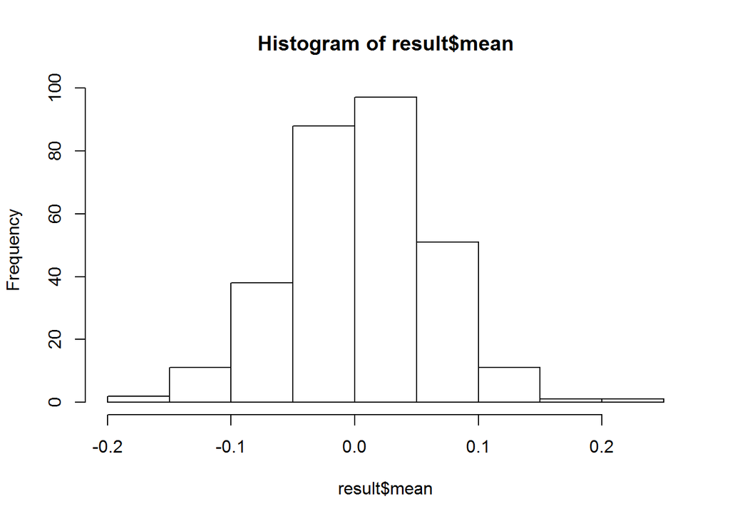

```r
hist(result$mean)  # just to see that the distribution looks right
```

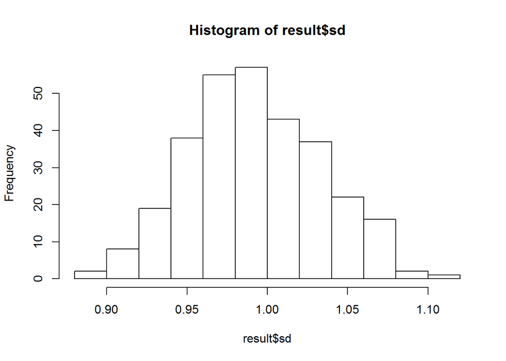

```r
hist(result$sd)
```

```r
# you can use 'keyby' to cause the output to be sorted by the 'by' condition
sorted_result <- myDT[, list(mean= mean(value),
                             sd = sd(value),
                             count = .N
                     ), keyby = list(id)]
head(sorted_result)
```

```
##    id         mean        sd count
## 1:  1  0.047962818 0.9699491   356
## 2:  2 -0.012132725 1.0683701   356
## 3:  3 -0.019028890 1.0232125   375
## 4:  4 -0.017762979 1.0117569   308
## 5:  5  0.005275044 1.0744915   348
## 6:  6 -0.014802969 0.9464754   338
```

Another operation that you can so is to specify a condition in the first position (**where**) that you want the operation to apply to, and then in the second position the operation you want to perform. For example, let’s add a column where is the **id** is less than 200, the column is set to 4. For those rows which are not affected, an **NA** will be stored.

```r
# call the column 'flag'
invisible(
  myDT[id < 200, flag := 4]  # this will do it
)
head(myDT)
```

```
##     id char_id      value         v2         v3         v4        v6
## 1: 147       Q  2.5517153  5.1034306  7.6551459 10.2068612 15.310292
## 2: 180       O  0.1915562  0.3831124  0.5746686  0.7662248  1.149337
## 3: 285       M -0.9771532 -1.9543065 -2.9314597 -3.9086130 -5.862919
## 4:  73       R -0.7896255 -1.5792510 -2.3688765 -3.1585020 -4.737753
## 5: 209       W -0.8664317 -1.7328634 -2.5992950 -3.4657267 -5.198590
## 6: 273       F -0.1863481 -0.3726962 -0.5590443 -0.7453924 -1.118089
##           v7        v8 flag
## 1: 17.862007 20.413722    4
## 2:  1.340893  1.532450    4
## 3: -6.840073 -7.817226   NA
## 4: -5.527378 -6.317004    4
## 5: -6.065022 -6.931453   NA
## 6: -1.304437 -1.490785   NA
```

So the ability to subset, aggregate/summarise and add/delete/change columns within the data.table with out making copies leads to some nice performance benefits with large tables. I have one table with 45M rows that I can summarise within a couple of seconds and make changes to without large copies being made.

## One Advantage/Disadvantage to be Aware of

We have indicated that copies are not being made because the operations on the **data.table** are performed by using a **reference** (pointer) to the data and not having to move the data itself. For example if you sort the data.table with the **setkey** or **setorder** functions, only an index is created which is the size of the number of rows in the data.table and it points to the row with the data in the **sorted** order, so the actual data.table elements are not moved, just an index added – this is an improvement in processing time and memory if the data.table is large.

So if I want to sort **myDT**, here how it would be done:

```r
address(myDT)
```

```
## [1] "0000000005EB9EA8"
```

```r
# use the setorder to specify the sort order
head(myDT)  # presort order
```

```
##     id char_id      value         v2         v3         v4        v6
## 1: 147       Q  2.5517153  5.1034306  7.6551459 10.2068612 15.310292
## 2: 180       O  0.1915562  0.3831124  0.5746686  0.7662248  1.149337
## 3: 285       M -0.9771532 -1.9543065 -2.9314597 -3.9086130 -5.862919
## 4:  73       R -0.7896255 -1.5792510 -2.3688765 -3.1585020 -4.737753
## 5: 209       W -0.8664317 -1.7328634 -2.5992950 -3.4657267 -5.198590
## 6: 273       F -0.1863481 -0.3726962 -0.5590443 -0.7453924 -1.118089
##           v7        v8 flag
## 1: 17.862007 20.413722    4
## 2:  1.340893  1.532450    4
## 3: -6.840073 -7.817226   NA
## 4: -5.527378 -6.317004    4
## 5: -6.065022 -6.931453   NA
## 6: -1.304437 -1.490785   NA
```

```r
# notice that I am not assigning back to myDT the result of the sort like
# I would do with a data.frame.  The 'setorder' function does not return
# a value, it just adds an index to the data.table
setorder(myDT, id)  # sort by the 'id'
head(myDT)  # should now be sorted
```

```
##    id char_id       value          v2          v3         v4         v6
## 1:  1       J  1.41144256  2.82288512  4.23432768  5.6457702  8.4686554
## 2:  1       E  3.16246716  6.32493433  9.48740149 12.6498687 18.9748030
## 3:  1       I -0.39802751 -0.79605501 -1.19408252 -1.5921100 -2.3881650
## 4:  1       U -0.12144413 -0.24288827 -0.36433240 -0.4857765 -0.7286648
## 5:  1       D  0.01723322  0.03446645  0.05169967  0.0689329  0.1033993
## 6:  1       R -1.28892915 -2.57785831 -3.86678746 -5.1557166 -7.7335749
##            v7          v8 flag
## 1:  9.8800979  11.2915405    4
## 2: 22.1372701  25.2997373    4
## 3: -2.7861925  -3.1842201    4
## 4: -0.8501089  -0.9715531    4
## 5:  0.1206326   0.1378658    4
## 6: -9.0225041 -10.3114332    4
```

```r
address(myDT)  # still should be the same address
```

```
## [1] "0000000005EB9EA8"
```

Now one of the results of this is that most people who are using **R** are use to functions not having any **side effects**; i.e., the function does not change the value of any objects passed to it, it only returns a value.

If you are using **data.tables** you **will** have to be careful in this area since in normal **R** processing, if you change one of the parameters sent to the function, a copy of the object is make, then changes made to the copy, and unless you return the changed object, it is just deleted from memory.

```r
# here is how a normal R function performs
# we will change the value in the function, but its value in the global
# enviroment is not changed
f_1 <- function(x) x <- 1  # function to set the value of 'x' to 1

x <- 42  # I will even use the same name as the parameter, though it does not matter
y <- f_1(x)  # 'y' get the value of the last operation in the function
x  # should still be 42
```

```
## [1] 42
```

```r
y  # should be 1
```

```
## [1] 1
```

```r
# now let's create a small data.table and see what happens if we modify it in the function
aDT <- data.table(x = 1:3, y = 11:13)

f_2 <- function(x){
  x[, z := x + y]  # operation on the data.table to add a column
  1  # return value
}

aDT  # before
```

```
##    x  y
## 1: 1 11
## 2: 2 12
## 3: 3 13
```

```r
address(aDT)
```

```
## [1] "000000000C1EC4E0"
```

```r
b <- f_2(aDT)  # call the function
b  # return value
```

```
## [1] 1
```

```r
aDT  # notice that the original as been changed
```

```
##    x  y  z
## 1: 1 11 12
## 2: 2 12 14
## 3: 3 13 16
```

```r
address(aDT)  # but the address is still the same
```

```
## [1] "000000000C1EC4E0"
```

I mentioned that this might be **good/bad**, but if you are aware of what is happening, and if you are operating on large objects, you can use functions to make changes to the data.table and copies are not being made, which is improving the performance.

You can execute any set of code in the second parameter. For example if I want to make a histogram of just **id == 42**, I could create a subset and then plot it:

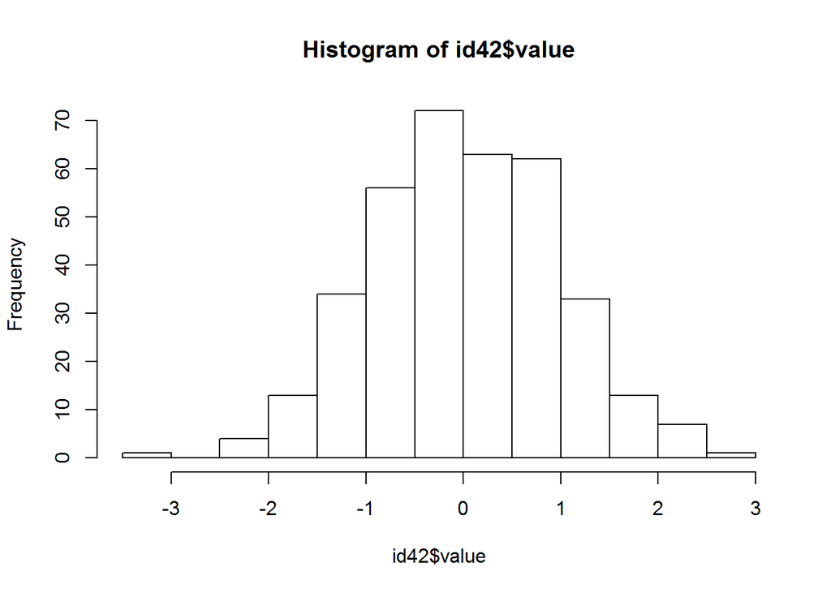

```r
# this is how I might do it by subsetting the object for a specific value
id42 <- myDT[id == 42]
hist(id42$value)
```

Or I could combine it all in one statement as follows:

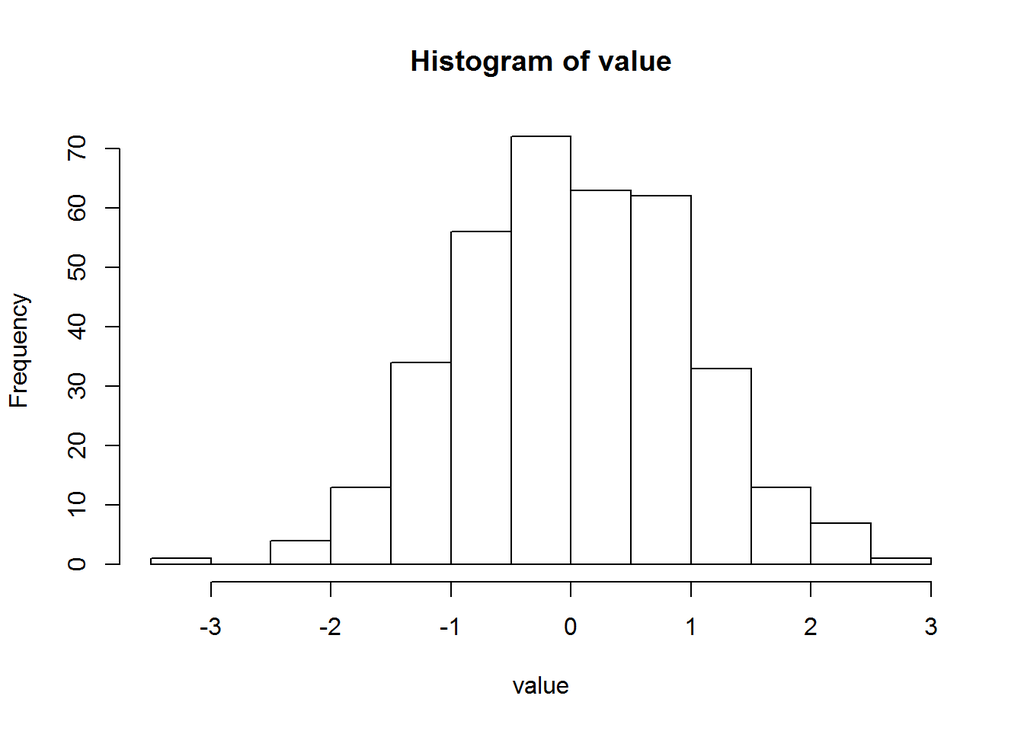

```r
invisible(
  myDT[id == 42, {hist(value)}]
)
```

I have access to all the different column and could create a fairly complex set of steps. This is very much the same as when you create an **anonomous** function in using one of the **apply** functions.

So this was a quick introduction to **data.table**. I have found it very useful with working with large object and making changes to various columns. The number of copies is reduced (you actually have to use the **copy** function to create a copy of a data.table). If you just assign it to another object, they will both point to the same data and changes made to one object appear in the other since the data is the same.

In the case of most other **R** objects (that are not data.tables), there is a *copy on modify* condition. Only when a change is made to an object that was assigned from another object is a copy done. This is **not** true for **data.table** objects. Here is information from Hadley’s **Advanced R** book:

**RC**

Reference classes (or **RC** for short) are the newest OO system in R. They were introduced in version 2.12. They are fundamentally different to S3 and S4 because:

- RC methods belong to objects, not functions
- RC objects are mutable: the usual R **copy-on-modify semantics do not apply**

These properties make RC objects behave more like objects do in most other programming languages, e.g., Python, Ruby, Java, and C#. Reference classes are implemented using R code: they are a special S4 class that wraps around an environment.

**data.table** object are a **reference class**.

```r
# create a small data.table object
a <- data.table(v=1:10)
b <- a  # assign 'a' to 'b'
# now change b
invisible(
  b[, new_col := 11:20]
)
head(b)
```

```
##    v new_col
## 1: 1      11
## 2: 2      12
## 3: 3      13
## 4: 4      14
## 5: 5      15
## 6: 6      16
```

```r
head(a)  # 'a' has also been changed
```

```
##    v new_col
## 1: 1      11
## 2: 2      12
## 3: 3      13
## 4: 4      14
## 5: 5      15
## 6: 6      16
```

Again, might be useful in some situation, **but be aware of it and be careful**.

## Setting a column to conditional values

Here is an example of a case where I had to set a column to values based on condition and values from other columns. There was an order to test for the conditions, and then a default value is none of the other conditions were TRUE.

In this case, the **v** column needs to be set to either **a** or **b** or **c** if it value is **NA** or **<=1**. Now one of the other columns may also have values **NA** or **<=1**, so we want to carry out the tests in specific order.

Notice that the condition that we are testing for is in the first positional parameter after the **[**, with the value in the second using the **:=** operator.

```r
library(knitr)
library(data.table)
# create a test dataframe
set.seed(1)
mydata <- data.table(name = paste0("line", 0:9),
                     v = sample(c(-1,5,NA), 10, TRUE),
                     a = sample(c(-1,2,NA), 10, TRUE),
                     b = sample(c(-1,3,NA), 10, TRUE),
                     c = sample(c(-1,4,NA), 10, TRUE)
)

# use 'kable' for nice looking tables
kable(mydata, caption = "Data Before")
```

Data Before

| name | v | a | b | c |
| --- | --- | --- | --- | --- |
| line0 | -1 | -1 | NA | 4 |
| line1 | 5 | -1 | -1 | 4 |
| line2 | 5 | NA | 3 | 4 |
| line3 | NA | 2 | -1 | -1 |
| line4 | -1 | NA | -1 | NA |
| line5 | NA | 2 | 3 | NA |
| line6 | NA | NA | -1 | NA |
| line7 | 5 | NA | 3 | -1 |
| line8 | 5 | 2 | NA | NA |
| line9 | -1 | NA | 3 | 4 |

```r
# now a series of statements to set 'v' to some value
# the order is important so that we pick the first valid data from the columns
# notice that the test condition is the same in all the statements
invisible({  # problem with 'knitr'
  mydata[is.na(v) | v <= 1, v := a]
  mydata[is.na(v) | v <= 1, v := b]
  mydata[is.na(v) | v <= 1, v := c]
  mydata[is.na(v) | v <= 1, v := 42]  # if all else fails, set a default
})

kable(mydata, caption = "Data After")
```

Data After

| name | v | a | b | c |
| --- | --- | --- | --- | --- |
| line0 | 4 | -1 | NA | 4 |
| line1 | 5 | -1 | -1 | 4 |
| line2 | 5 | NA | 3 | 4 |
| line3 | 2 | 2 | -1 | -1 |
| line4 | 42 | NA | -1 | NA |
| line5 | 2 | 2 | 3 | NA |
| line6 | 42 | NA | -1 | NA |
| line7 | 5 | NA | 3 | -1 |
| line8 | 5 | 2 | NA | NA |
| line9 | 3 | NA | 3 | 4 |

So start to use **data.table** if you have some big data.frames, but watch out for some of the things I have mentioned above.